# Proyección de Inflación en Bolivia

SARIMA, SARIMAX e Intervenciones

Análisis Econométrico

26 de junio de 2026

# 1 Datos y Descomposición Estacional

Serie: **log(IPC)** desde enero 2019 (89 observaciones mensuales). Período suficiente para estimar componentes estacionales con $s = 12$.

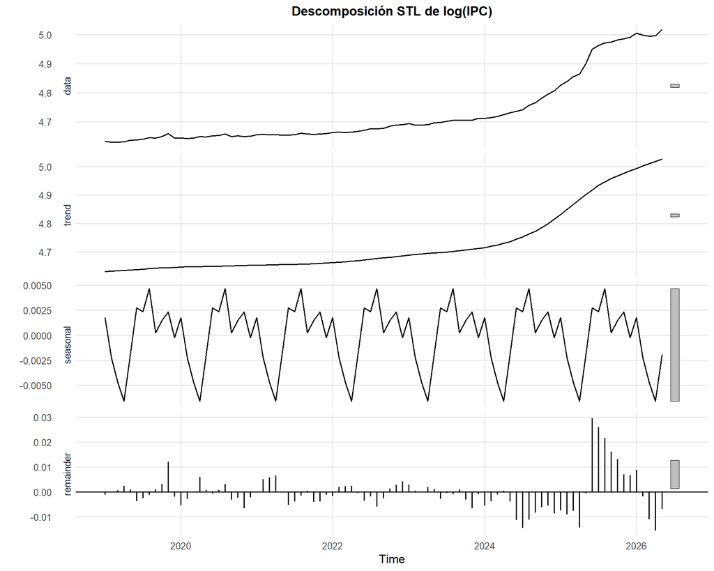

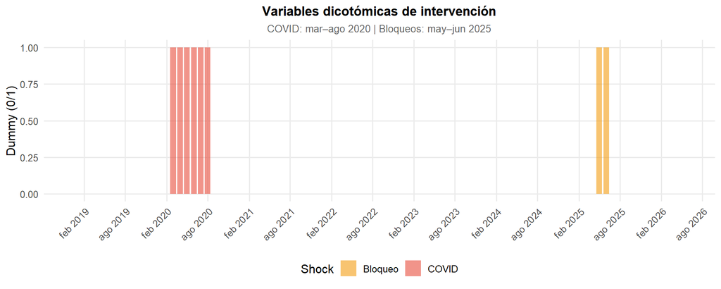

# 2 Pruebas de Raíz Unitaria y Estacionalidad

Pruebas de raíz unitaria

| Prueba | H₀ | Rechazo | Serie | Estadístico | p-valor | Conclusión |
| --- | --- | --- | --- | --- | --- | --- |
| **log(IPC)** |  |  |  |  |  |  |
| ADF | Raíz unitaria | p<0.05 → Estac. | log(IPC) | -0.4359 | 0.9827 | No estac. |
| PP | Raíz unitaria | p<0.05 → Estac. | log(IPC) | 0.2043 | 0.9900 | No estac. |
| KPSS | Estacionaria | p<0.05 → No estac. | log(IPC) | 1.7474 | 0.0100 | No estac. |
| **Δlog(IPC)** |  |  |  |  |  |  |
| ADF | Raíz unitaria | p<0.05 → Estac. | Δlog(IPC) | -2.7648 | 0.2616 | No estac. |
| PP | Raíz unitaria | p<0.05 → Estac. | Δlog(IPC) | -53.0083 | 0.0100 | Estac. |
| KPSS | Estacionaria | p<0.05 → No estac. | Δlog(IPC) | 0.9652 | 0.0100 | No estac. |

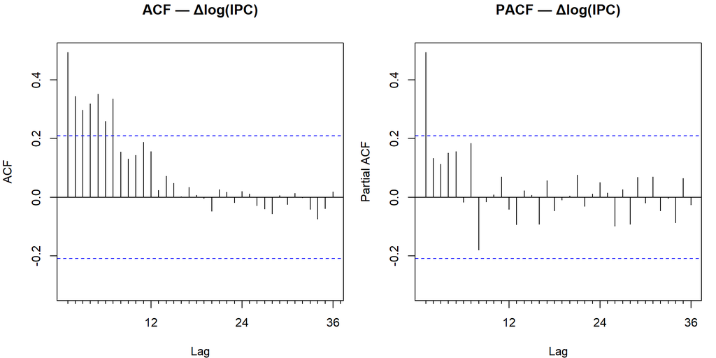

# 3 Modelo A: SARIMA Puro

Se estiman SARIMA$(p,d,q)(P,D,Q)_{12}$ sobre log(IPC) con $d=1$, $D=0$, $p,q \in [0,3]$, $P,Q \in [0,1]$.

Modelo A: SARIMA puro — Top 15 de 63 modelos

| Modelo | AICc | BIC | HQ | RMSE | MAPE | LB(p) | Score |
| --- | --- | --- | --- | --- | --- | --- | --- |
| (2,1,2)(1,0,0)[12] | -614.84 | -601.01 | -609.89 | 0.00668 | 0.088 | 0.9451 | -2.165 |
| (2,1,2)(0,0,1)[12] | -614.58 | -600.75 | -609.63 | 0.00671 | 0.088 | 0.9399 | -2.097 |
| (3,1,3)(1,0,0)[12] | -611.75 | -593.75 | -605.59 | 0.00651 | 0.085 | 0.9007 | -2.080 |
| (3,1,3)(1,0,1)[12] | -610.87 | -590.88 | -604.19 | 0.00641 | 0.084 | 0.9405 | -1.999 |
| (3,1,3)(0,0,0)[12] | -611.30 | -595.36 | -605.72 | 0.00666 | 0.085 | 0.7773 | -1.955 |
| (2,1,2)(1,0,1)[12] | -614.22 | -598.28 | -608.63 | 0.00661 | 0.088 | 0.9547 | -1.935 |
| (3,1,3)(0,0,1)[12] | -611.30 | -593.30 | -605.13 | 0.00653 | 0.086 | 0.8752 | -1.890 |
| (2,1,2)(0,0,0)[12] | -614.35 | -602.69 | -610.09 | 0.00685 | 0.089 | 0.9023 | -1.868 |
| (3,1,2)(0,0,1)[12] | -613.09 | -597.14 | -607.50 | 0.00666 | 0.087 | 0.9363 | -1.779 |
| (3,1,2)(1,0,0)[12] | -613.33 | -597.39 | -607.74 | 0.00666 | 0.088 | 0.9459 | -1.753 |
| (3,1,2)(1,0,1)[12] | -612.64 | -594.64 | -606.48 | 0.00656 | 0.087 | 0.9628 | -1.741 |
| (2,1,3)(0,0,1)[12] | -612.99 | -597.04 | -607.40 | 0.00667 | 0.088 | 0.9363 | -1.721 |
| (2,1,3)(1,0,1)[12] | -612.63 | -594.63 | -606.47 | 0.00656 | 0.087 | 0.9642 | -1.696 |
| (3,1,2)(0,0,0)[12] | -612.74 | -598.91 | -607.79 | 0.00681 | 0.088 | 0.8590 | -1.625 |
| (1,1,2)(1,0,1)[12] | -613.02 | -599.20 | -608.07 | 0.00676 | 0.089 | 0.9596 | -1.448 |

> **Ganador A:** (2,1,2)(1,0,0)[12] (Score = -2.165)

# 4 Modelo B: SARIMA + Intervenciones

Se agregan dummies de **COVID** (mar–ago 2020) y **Bloqueos** (may–jun 2025) como regresores exógenos al SARIMA. Esto permite capturar los shocks sin que contaminen la estructura ARMA.

Modelo B: SARIMA + Intervenciones — Top 15 de 63 modelos

| Modelo | AICc | BIC | HQ | RMSE | MAPE | LB(p) | Score |
| --- | --- | --- | --- | --- | --- | --- | --- |
| (2,1,2)(0,0,0)[12] | -618.74 | -602.80 | -613.15 | 0.00651 | 0.084 | 0.7759 | -2.227 |
| (2,1,3)(0,0,0)[12] | -617.33 | -599.33 | -611.17 | 0.00647 | 0.084 | 0.8021 | -1.974 |
| (3,1,2)(0,0,0)[12] | -617.47 | -599.48 | -611.31 | 0.00647 | 0.084 | 0.8035 | -1.973 |
| (2,1,2)(1,0,1)[12] | -617.07 | -597.09 | -610.40 | 0.00633 | 0.084 | 0.7970 | -1.892 |
| (3,1,3)(1,0,1)[12] | -612.45 | -588.67 | -604.94 | 0.00621 | 0.080 | 0.8531 | -1.776 |
| (2,1,1)(0,0,0)[12] | -618.14 | -604.31 | -613.18 | 0.00665 | 0.087 | 0.7974 | -1.763 |
| (2,1,2)(1,0,0)[12] | -617.37 | -599.37 | -611.21 | 0.00646 | 0.085 | 0.8166 | -1.743 |
| (1,1,1)(0,0,0)[12] | -617.15 | -605.50 | -612.90 | 0.00678 | 0.086 | 0.6507 | -1.734 |
| (2,1,2)(0,0,1)[12] | -617.25 | -599.26 | -611.09 | 0.00647 | 0.085 | 0.8199 | -1.722 |
| (1,1,2)(0,0,0)[12] | -618.49 | -604.66 | -613.54 | 0.00664 | 0.088 | 0.7962 | -1.637 |
| (3,1,3)(0,0,0)[12] | -615.16 | -595.17 | -608.49 | 0.00645 | 0.083 | 0.8332 | -1.616 |
| (3,1,2)(1,0,1)[12] | -615.55 | -593.64 | -608.43 | 0.00629 | 0.084 | 0.8550 | -1.609 |
| (2,1,3)(1,0,1)[12] | -615.59 | -593.68 | -608.47 | 0.00629 | 0.084 | 0.8743 | -1.594 |
| (2,1,3)(1,0,0)[12] | -616.03 | -596.04 | -609.35 | 0.00638 | 0.085 | 0.8699 | -1.580 |
| (3,1,2)(1,0,0)[12] | -616.07 | -596.09 | -609.40 | 0.00640 | 0.085 | 0.8576 | -1.545 |

Efecto estimado de las intervenciones sobre log(IPC)

Intervención

Coeficiente

Err. Std.

z

p-valor

COVID

0.00837

0.00463

1.809

0.0704

Bloqueo

0.01114

0.00448

2.486

0.0129

> **Ganador B:** (2,1,2)(0,0,0)[12] (Score = -2.227)

# 5 Modelo C: SARIMAX (con tipo de cambio)

Se incorporan **TC digital** y **TC referencial** como variables exógenas, junto a las dummies de intervención. Los valores faltantes de TC se interpolan (zoo::na.approx) dado que TC digital inicia en oct-2023 y TC referencial finaliza en nov-2025.

Modelo C: SARIMAX — Top 15 de 35 modelos

| Modelo | AICc | BIC | HQ | RMSE | MAPE | LB(p) | Score |
| --- | --- | --- | --- | --- | --- | --- | --- |
| (2,1,2)(0,0,0)[12] | -614.99 | -595.00 | -608.32 | 0.00647 | 0.084 | 0.7084 | -2.406 |
| (2,1,1)(0,0,0)[12] | -614.09 | -596.09 | -607.93 | 0.00662 | 0.086 | 0.7070 | -2.084 |
| (1,1,2)(0,0,0)[12] | -614.71 | -596.71 | -608.54 | 0.00660 | 0.086 | 0.6601 | -2.041 |
| (1,1,1)(0,0,0)[12] | -613.39 | -597.44 | -607.80 | 0.00674 | 0.086 | 0.7789 | -1.957 |
| (2,1,2)(1,0,0)[12] | -613.03 | -591.11 | -605.91 | 0.00644 | 0.084 | 0.6964 | -1.915 |
| (2,1,2)(0,0,1)[12] | -612.96 | -591.05 | -605.84 | 0.00644 | 0.084 | 0.7028 | -1.899 |
| (2,1,2)(1,0,1)[12] | -612.55 | -588.77 | -605.05 | 0.00630 | 0.084 | 0.6616 | -1.884 |
| (1,1,2)(1,0,1)[12] | -612.29 | -590.37 | -605.16 | 0.00643 | 0.086 | 0.7553 | -1.613 |
| (2,1,1)(1,0,1)[12] | -611.34 | -589.42 | -604.21 | 0.00647 | 0.085 | 0.7228 | -1.573 |
| (2,1,1)(1,0,0)[12] | -612.08 | -592.09 | -605.41 | 0.00659 | 0.086 | 0.6931 | -1.534 |
| (1,1,1)(1,0,1)[12] | -610.83 | -590.84 | -604.15 | 0.00658 | 0.086 | 0.6761 | -1.520 |
| (2,1,1)(0,0,1)[12] | -612.01 | -592.02 | -605.33 | 0.00660 | 0.086 | 0.6886 | -1.515 |
| (1,1,2)(1,0,0)[12] | -612.84 | -592.86 | -606.17 | 0.00656 | 0.087 | 0.6984 | -1.481 |
| (1,1,2)(0,0,1)[12] | -612.73 | -592.75 | -606.06 | 0.00657 | 0.087 | 0.6821 | -1.455 |
| (1,1,1)(0,0,1)[12] | -611.14 | -593.14 | -604.97 | 0.00673 | 0.087 | 0.6983 | -1.259 |

Coeficientes de regresores exógenos en SARIMAX

Variable

Coeficiente

Err. Std.

z

p-valor

COVID

0.00851

0.00468

1.819

0.0690

Bloqueo

0.00738

0.00602

1.225

0.2206

TC_dig

0.00185

0.00180

1.025

0.3052

TC_ref

-0.00005

0.00173

-0.030

0.9760

> **Ganador C:** (2,1,2)(0,0,0)[12] (Score = -2.406)

# 6 Comparación de los Tres Enfoques

Comparación de los tres enfoques

| Criterio | A: SARIMA | B: + Intervenciones | C: + TC exógeno |
| --- | --- | --- | --- |
| Modelo | (2,1,2)(1,0,0)[12] | (2,1,2)(0,0,0)[12] | (2,1,2)(0,0,0)[12] |
| Score | -2.165 | -2.227 | -2.406 |
| AICc | -614.84 | -618.74 | -614.99 |
| BIC | -601.01 | -602.8 | -595 |
| HQ | -609.89 | -613.15 | -608.32 |
| RMSE | 0.00668 | 0.00651 | 0.00647 |
| MAPE | 0.088 | 0.084 | 0.084 |
| Ljung-Box (p) | 0.9451 | 0.7759 | 0.7084 |

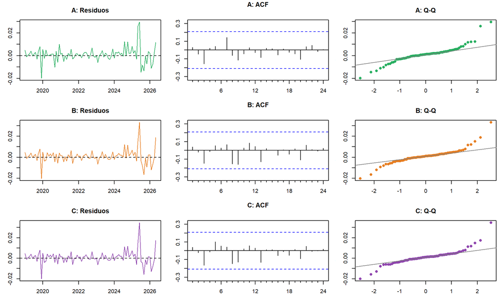

# 7 Backtesting

Backtesting — IPC pronosticado por modelo

| Fecha | IPC obs. | A: SARIMA | B: +Interv. | C: +TC |
| --- | --- | --- | --- | --- |
| dic 2025 | 147.14 | 146.92 | 146.89 | 146.83 |
| ene 2026 | 149.06 | 148.13 | 148.08 | 148.48 |
| feb 2026 | 148.14 | 148.79 | 148.75 | 149.59 |
| mar 2026 | 147.63 | 149.81 | 149.71 | 151.08 |
| abr 2026 | 147.84 | 150.45 | 150.37 | 152.32 |
| may 2026 | 150.98 | 151.27 | 151.17 | 153.74 |

Métricas de backtesting comparadas

| Métrica | A: SARIMA | B: +Interv. | C: +TC |
| --- | --- | --- | --- |
| RMSE (IPC) | 1.4706 | 1.4224 | 2.6505 |
| MAPE (IPC %) | 0.77% | 0.75% | 1.46% |

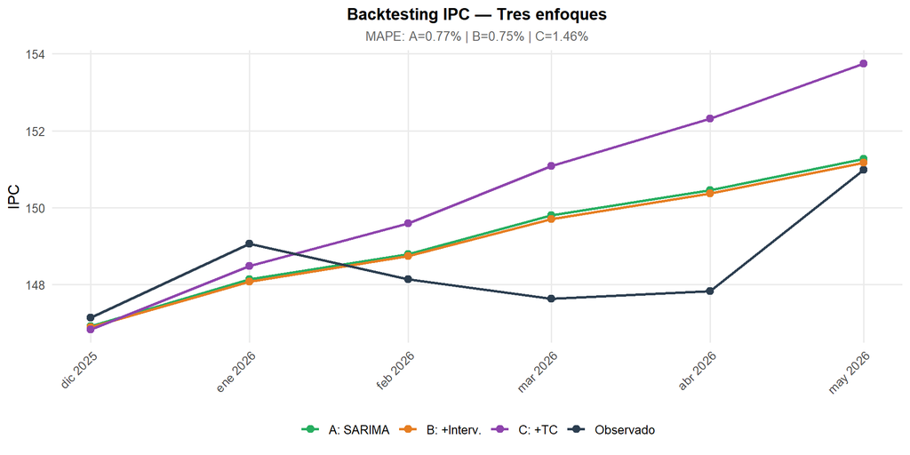

# 8 Pronóstico

## 8.1 Proyección comparada — Inflación

Proyección de inflación (%) — Tres enfoques

| Mes | A mens. | A interan. | B mens. | B interan. | C mens. | C interan. |
| --- | --- | --- | --- | --- | --- | --- |
| Junio | 1.655 | 8.71 | 0.997 | 8.01 | 1.001 | 8.01 |
| Julio | 0.517 | 7.98 | 0.474 | 7.23 | 0.451 | 7.21 |
| Agosto | 0.485 | 7.42 | 0.803 | 7.02 | 0.805 | 7.00 |
| Septiembre | 0.210 | 7.43 | 0.487 | 7.32 | 0.485 | 7.30 |
| Octubre | 0.369 | 7.02 | 0.665 | 7.23 | 0.673 | 7.22 |
| Noviembre | 0.231 | 6.84 | 0.471 | 7.31 | 0.483 | 7.31 |
| Diciembre | 0.289 | 6.52 | 0.564 | 7.28 | 0.578 | 7.30 |

## 8.2 Inflación interanual — Tres enfoques

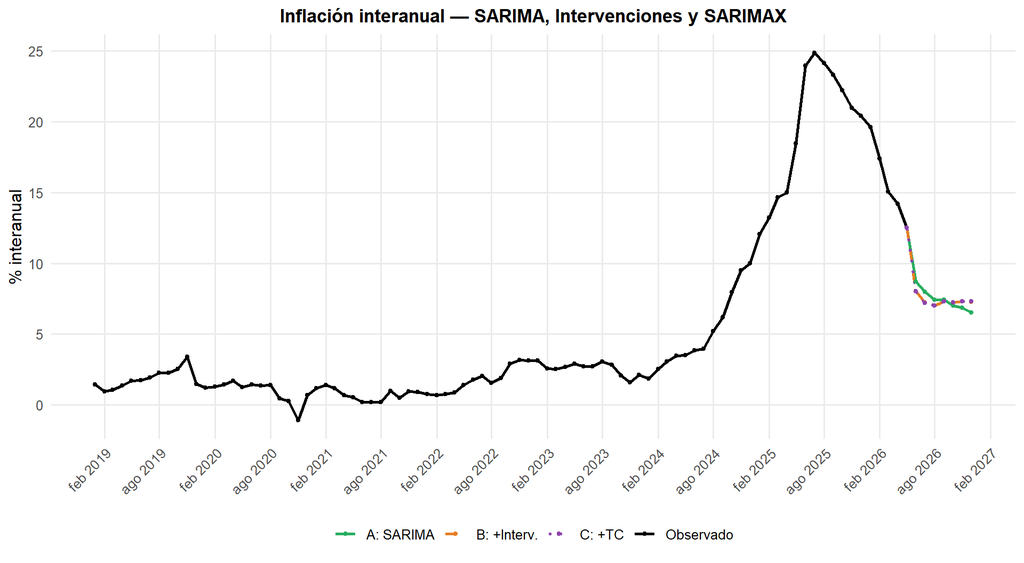

## 8.3 Contrafactual vs. Post-Bloqueos

Contrafactual SARIMA+Interv. vs. escenario post-bloqueos

| Mes | Contrafactual (B) % | Post-bloqueos % | Diferencia (pp) |
| --- | --- | --- | --- |
| Julio | 7.23 | 12.70 | 5.47 |
| Agosto | 7.02 | 13.40 | 6.38 |
| Septiembre | 7.32 | 14.63 | 7.31 |
| Octubre | 7.23 | 15.38 | 8.15 |
| Noviembre | 7.31 | 16.29 | 8.98 |
| Diciembre | 7.28 | 16.90 | 9.62 |

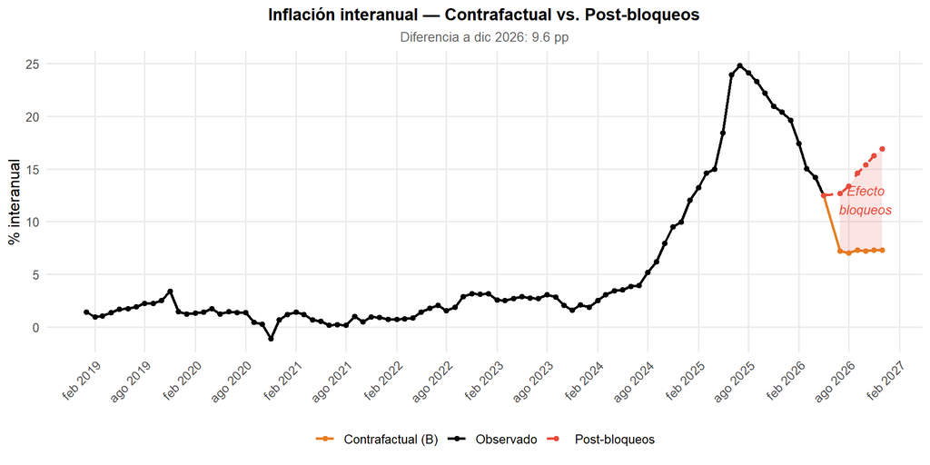

*Modelos estimados sobre log(IPC) desde 2019 (n=89).* *A: SARIMA puro | B: + dummies COVID y Bloqueos | C: + TC digital y referencial.*